# TDaun_Livesession3assignment

Travis Daun

11/23/2018

## Question 1

- > mkdir AwesomePublicDatasets
- > cd AwesomePublicDatasets
- > git clone https://github.com/caesar0301/awesome-public-datasets

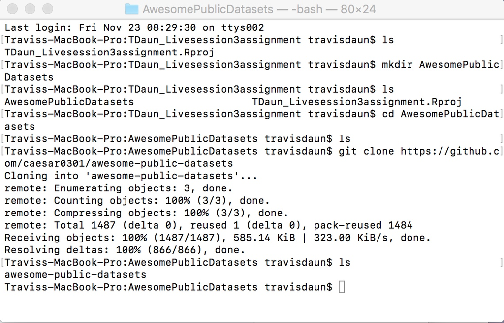

## Question 2

### a. Read in titanic.csv

```r
df <- read.csv("AwesomePublicDatasets/awesome-public-datasets/Datasets/titanic.csv")
head(df)
```

```
##   PassengerId Survived Pclass
## 1           1        0      3
## 2           2        1      1
## 3           3        1      3
## 4           4        1      1
## 5           5        0      3
## 6           6        0      3
##                                                  Name    Sex Age SibSp
## 1                             Braund, Mr. Owen Harris   male  22     1
## 2 Cumings, Mrs. John Bradley (Florence Briggs Thayer) female  38     1
## 3                              Heikkinen, Miss. Laina female  26     0
## 4        Futrelle, Mrs. Jacques Heath (Lily May Peel) female  35     1
## 5                            Allen, Mr. William Henry   male  35     0
## 6                                    Moran, Mr. James   male  NA     0
##   Parch           Ticket    Fare Cabin Embarked
## 1     0        A/5 21171  7.2500              S
## 2     0         PC 17599 71.2833   C85        C
## 3     0 STON/O2. 3101282  7.9250              S
## 4     0           113803 53.1000  C123        S
## 5     0           373450  8.0500              S
## 6     0           330877  8.4583              Q
```

### b. Output the respective count of females and males aboard the Titanic. Plot the frequency of females and males. Be sure to give an accurate title and label the axes.

```r
Sex <- sapply(df$Sex, as.numeric)
female <- length(which(Sex==1))
male <- length(which(Sex==2))
female
```

```
## [1] 314
```

```r
male
```

```
## [1] 577
```

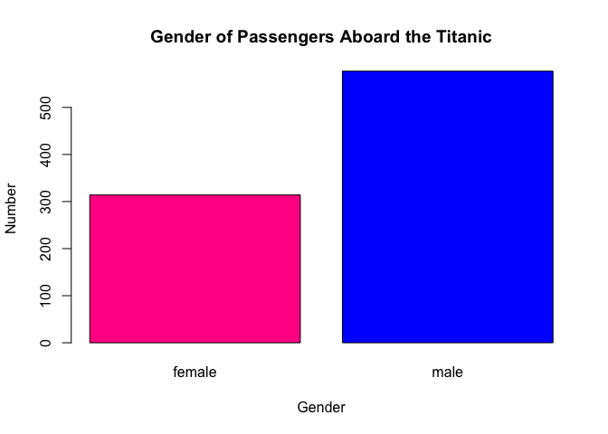

```r
plot(df$Sex, main="Gender of Passengers Aboard the Titanic",
     ylab="Number", xlab="Gender", col=c("deeppink","blue"))
```

### c. Please use one apply function (to review: swirl() modules 11, 12) to output the means of Age, Fare, and Survival. Make sure the output is a real number for all three means.

```r
P2cdf <- data.frame(df$Age)
P2cdf <- cbind(P2cdf, df$Fare)
P2cdf <- cbind(P2cdf, df$Survived)
colnames(P2cdf) <- c("Age", "Fare", "Survived")
sapply(na.omit(P2cdf), mean)
```

```
##        Age       Fare   Survived
## 29.6991176 34.6945140  0.4061625
```

## Question 3

```r
myFunction <- function(x) {
  median_Age <- median(x$Age, na.rm=TRUE)
  min_Duration <- min(x$Duration, na.rm=TRUE)
  max_Duration <- max(x$Duration, na.rm=TRUE)
  mean_RSES <- mean(x$RSES, na.rm = TRUE)
  sd_RSES <- sd(x$RSES, na.rm = TRUE)
  report <- data.frame(median_Age)
  report <- cbind(report, (mean_RSES/5))
  report <- cbind(report, (sd_RSES/5))
  report <- cbind(report, (max_Duration-min_Duration))
  colnames(report) <- c("MedianAge", "SelfEsteem", "SE_SD", "DurationRange")
  round(report, digits = 2)
}
```

### Run the function on sleep_data_01.csv

```r
sleep <- read.csv("sleep_data_01.csv")

myFunction(sleep)
```

```
##   MedianAge SelfEsteem SE_SD DurationRange
## 1        14       3.62  1.24             7
```

## Question 4

```r
library(fivethirtyeight)
df <- fivethirtyeight::college_recent_grads
```

- https://fivethirtyeight.com/features/the-economic-guide-to-picking-a-college-major/

```r
dim(df)
```

```
## [1] 173  21
```

```r
colnames(df)
```

```
##  [1] "rank"                        "major_code"
##  [3] "major"                       "major_category"
##  [5] "total"                       "sample_size"
##  [7] "men"                         "women"
##  [9] "sharewomen"                  "employed"
## [11] "employed_fulltime"           "employed_parttime"
## [13] "employed_fulltime_yearround" "unemployed"
## [15] "unemployment_rate"           "p25th"
## [17] "median"                      "p75th"
## [19] "college_jobs"                "non_college_jobs"
## [21] "low_wage_jobs"
```

## Question 5

1. Write an R command that gives you the column names of the data frame. Right after that, write one that counts the number of columns but not rows. Hint: The number should match one of your numbers in Question 1d for dimensions.

```r
colnames(df)
```

```
##  [1] "rank"                        "major_code"
##  [3] "major"                       "major_category"
##  [5] "total"                       "sample_size"
##  [7] "men"                         "women"
##  [9] "sharewomen"                  "employed"
## [11] "employed_fulltime"           "employed_parttime"
## [13] "employed_fulltime_yearround" "unemployed"
## [15] "unemployment_rate"           "p25th"
## [17] "median"                      "p75th"
## [19] "college_jobs"                "non_college_jobs"
## [21] "low_wage_jobs"
```

```r
ncol(df)
```

```
## [1] 21
```

2. Generate a count of each unique major_category in the data frame. I recommend using libraries to help. To be clear, this should look like a matrix or data frame containing the major_category and the frequency it occurs in the dataset. Assign it to major_count.

```r
library(dplyr)
major_count <- df %>% group_by(df$major_category) %>% summarize(count=n())
class(major_count)
```

```
## [1] "tbl_df"     "tbl"        "data.frame"
```

```r
major_count
```

```
## # A tibble: 16 x 2
##    `df$major_category`                 count
##    <chr>                               <int>
##  1 Agriculture & Natural Resources        10
##  2 Arts                                    8
##  3 Biology & Life Science                 14
##  4 Business                               13
##  5 Communications & Journalism             4
##  6 Computers & Mathematics                11
##  7 Education                              16
##  8 Engineering                            29
##  9 Health                                 12
## 10 Humanities & Liberal Arts              15
## 11 Industrial Arts & Consumer Services     7
## 12 Interdisciplinary                       1
## 13 Law & Public Policy                     5
## 14 Physical Sciences                      10
## 15 Psychology & Social Work                9
## 16 Social Science                          9
```

3. barplot of major_count

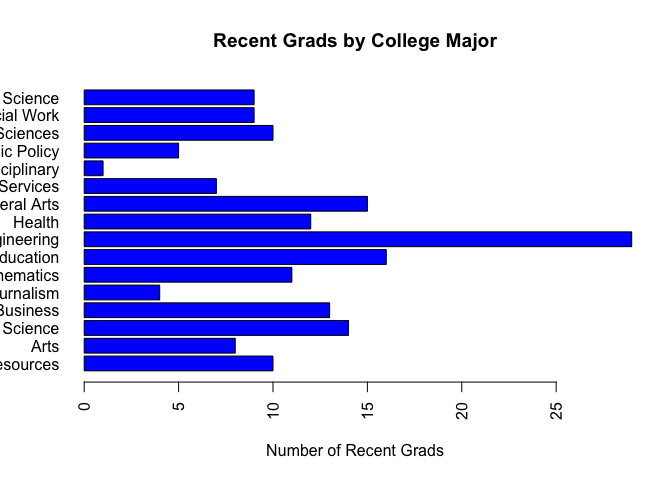

```r
par(las=2)
barplot(major_count$count, names.arg=major_count$`df$major_category`, horiz = TRUE,
        xlab ="Number of Recent Grads", main="Recent Grads by College Major", col="blue")
```

4. write fivethirtyeight data to a csv file.

```r
write.csv(df, file = "fivethirtyeightdata.csv",row.names=FALSE)
```

## Question 6

## https://github.com/dauntr/SMU_MSDS_Homework